# Simulating the effects of network coherence on community response to perturbations

Dominique Caron

2024-06-10

## Introduction

In this document, we demonstrate how the effects of network coherence on community response to a perturbation was simulated (so far). We first demonstrate how network coherence is defined in our simulations which use a Lotka-Volterra model. We then illustrate how simulations are performed with a step-by-step example.

1. Simulate an interaction matrix, making sure the equilibrium is stable
2. Generate species intrinsic growth rates, making sure that all species have positive biomasses at equilibrium
3. Simulate a perturbation by changing the intrinsic growth rates of species
4. Calculate network coherence

## Defining network coherence in Lotka-Volterra model

In our simulation, we will use a set of ordinary differential equations (sorry for mathematical notation, I don’t often do “demonstrations”; this is based on a quick demonstration that Dom G did during the in-person meeting.):

$$\begin{equation}
\tag{1}
\frac{dx_i}{dt} = x_i(\boldsymbol{r} + A \boldsymbol{x})
\end{equation}$$

where $\boldsymbol{x}$ is the vector of species biomass, $\boldsymbol{r}$ the vector of intrinsic growth rates, and $A$ the interaction matrix.

At equilibrium, we have:

$$\begin{equation}
\tag{2}
\boldsymbol{x} = -A^{-1} \boldsymbol{r}
\end{equation}$$

If we apply a perturbation and assumes that interactions are not changed, we can show that the change in abundances pre- to post- perturbation is defined by:

$$\begin{equation}
\tag{3}
\boldsymbol{\Delta x} = -A^{-1} \boldsymbol{\Delta r}
\end{equation}$$

If we focus on changes for species i and seperate intra-specific and inter-specifc effects:

$$\begin{equation}
\tag{4}
\Delta x_i = -a_{ii}^{-1} \Delta r_i - \sum a_{ij}^{-1} \Delta r_j,
\end{equation}$$

where $j \neq i$.

In the context of network coherence, we are interested in the second term of the sum (interspecific effects).

We have the following theorems on the expectation of product of two random variables:
$$\begin{equation}
\tag{5}
E[XY] = E[X]E[Y] + cov(X,Y)
\end{equation}$$

and on the expectation of sums of random variables:
$$\begin{equation}
\tag{6}
E[\sum X] = \sum E[X]
\end{equation}$$

So, we have the following expectation for the second term:
$$\begin{equation}
\tag{7}
E[\sum a_{ij} \Delta r_j] = E[a_{ij}^{-1}] E[\Delta r_j] +
cov(a_{ij}^{-1}, \Delta r_j),
\end{equation}$$

where $i \neq j$.

This last term is what we define here as the network coherence for specie $i$ and is the covariance between the net effects of all other species $j$ on $i$ ($a_{ij}^{-1}$) and the intrinsic responses of species $j$ ($\Delta r_{j \neq i}$).

## Parametrization

Before beginning, let’s set some parameters of the simulation. For this example, we will simlulate a predator-prey network of 10 species.

```r
params <- list(

  # number of species
  S = 10,

  # simulating interaction networks
  Net_type = "predator-prey", # type of network: predator-prey, mutualistic, competition
  C = 0.2, # connectance
  aij_params = c(0, 0.1), # mean and standard deviation of interaction strength
  rho = 0,

  # simulating species responses to an environmental perturbation
  delta_r_params = c(0, 1), # mean and standard deviation of the changes in species growth rates after the perturbation (squared)

  # simulating species dynamics
  maxt = 100 # number of time steps before and after the perturbation
)
```

## Step 1: Simulate an interaction matrix

First, we randomly simulate an predator-prey network. To do so, we set positive effects of prey on predators and negative effect of predators on prey. Here is the code of the function

```r
sim_quantitative_network
```

```
## function (Net_type, S, C, aij_params, rho = 0)
## {
##     A <- matrix(0, S, S)
##     n_pairs <- S * (S - 1)/2
##     B <- runif(n_pairs) <= C
##     if (Net_type == "random") {
##         A[upper.tri(A)] <- B * rnorm(n_pairs, aij_params[1],
##             aij_params[2])
##         A <- t(A)
##         A[upper.tri(A)] <- B * rnorm(n_pairs, aij_params[1],
##             aij_params[2])
##     }
##     else if (Net_type == "predator-prey") {
##         aij <- -abs(rnorm(n_pairs, aij_params[1], aij_params[2]))
##         A[upper.tri(A)] <- B * aij
##         A <- t(A)
##         aij <- abs(rnorm(n_pairs, aij_params[1], aij_params[2]))
##         A[upper.tri(A)] <- B * aij
##     }
##     else if (Net_type == "competition") {
##         aij <- -abs(rnorm(n_pairs * 2, aij_params[1], aij_params[2]))
##         A[upper.tri(A)] <- B * aij[1:n_pairs]
##         A <- t(A)
##         A[upper.tri(A)] <- B * aij[(n_pairs + 1):length(aij)]
##     }
##     else if (Net_type == "mutualistic") {
##         aij <- abs(rnorm(n_pairs * 2, aij_params[1], aij_params[2]))
##         A[upper.tri(A)] <- B * aij[1:n_pairs]
##         A <- t(A)
##         A[upper.tri(A)] <- B * aij[(n_pairs + 1):length(aij)]
##     }
##     else {
##         stop("Incorrect network type")
##     }
##     diag(A) <- -runif(S, min = 0, max = 1)
##     while (max(Re(eigen(A)$values)) > 0) {
##         diag(A) <- -runif(S, min = 0, max = 1)
##     }
##     return(A)
## }
```

Let’s simulate a network

```r
A <- with(params, sim_quantitative_network(Net_type, S, C, aij_params, rho))
kable(A, digits = 2)
```

| -0.34 | 0.00 | 0.00 | 0.05 | 0.01 | 0.00 | 0.00 | 0.00 | 0.00 | 0.00 |
| --- | --- | --- | --- | --- | --- | --- | --- | --- | --- |
| 0.00 | -0.96 | 0.00 | 0.00 | 0.00 | 0.00 | 0.05 | 0.00 | 0.00 | 0.00 |
| 0.00 | 0.00 | -0.54 | 0.00 | 0.00 | 0.05 | 0.00 | 0.00 | 0.00 | 0.00 |
| -0.18 | 0.00 | 0.00 | -0.36 | 0.00 | 0.00 | 0.00 | 0.00 | 0.00 | 0.00 |
| 0.00 | 0.00 | 0.00 | 0.00 | -0.12 | 0.00 | 0.00 | 0.00 | 0.06 | 0.00 |
| 0.00 | 0.00 | -0.01 | 0.00 | 0.00 | -0.05 | 0.00 | 0.00 | 0.00 | 0.00 |
| 0.00 | -0.03 | 0.00 | 0.00 | 0.00 | 0.00 | -0.46 | 0.18 | 0.00 | 0.00 |
| 0.00 | 0.00 | 0.00 | 0.00 | 0.00 | 0.00 | -0.01 | -0.34 | 0.04 | 0.00 |
| 0.00 | 0.00 | 0.00 | 0.00 | -0.12 | 0.00 | 0.00 | -0.10 | -0.08 | 0.00 |
| 0.00 | 0.00 | 0.00 | 0.00 | 0.00 | 0.00 | 0.00 | 0.00 | -0.18 | -0.01 |

## Step 2: Generate intrinsic growth rates

Next, we generate intrinsic growth rates that allow species to persist with positive biomasses when the system is at equilibrium.

```r
      Biomass_at_equilibrium <- runif(params$S, 1, 10)
      r <- -A%*%Biomass_at_equilibrium
      print(r)
```

```
##               [,1]
##  [1,]  1.552310638
##  [2,]  3.883229438
##  [3,]  2.575212136
##  [4,]  1.806294391
##  [5,] -0.005376605
##  [6,]  0.277110930
##  [7,]  0.200754613
##  [8,]  1.575365452
##  [9,]  0.911168589
## [10,]  0.614167366
```

Let’s see what the dynamic of the system look like:

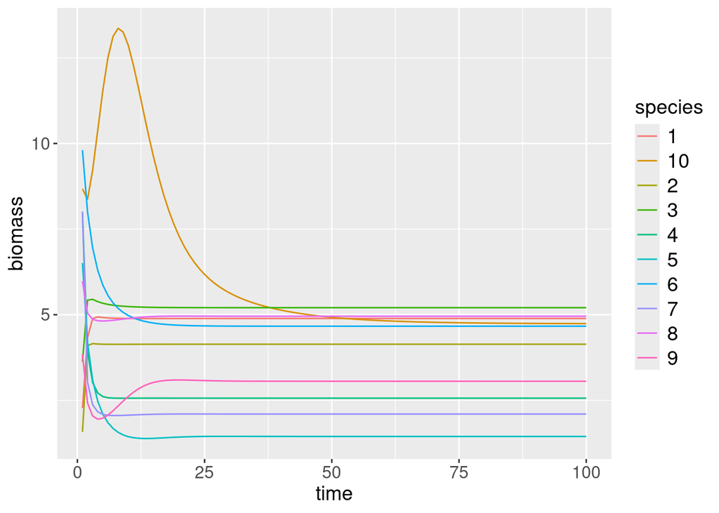

As expected, the system goes quickly to a stable equilibrium.

## Step 3: Simulate a perturbation

The third step is to simulate a perturbation. To do so, we will apply a change to the intrinsic growth rate of each species:

```r
      delta_r <- rnorm(10, mean = params$delta_r_params[1], sd = params$delta_r_params[2])
      new_r <- r + delta_r
      delta_r
```

```
##  [1]  1.7601727  0.1267466 -0.9673113  1.2687174  0.2549619 -0.0317945
##  [7] -1.2138909  1.2599897  0.3079348 -0.3825717
```

Let’s see what the dynamic look like pre- and post-perturbation

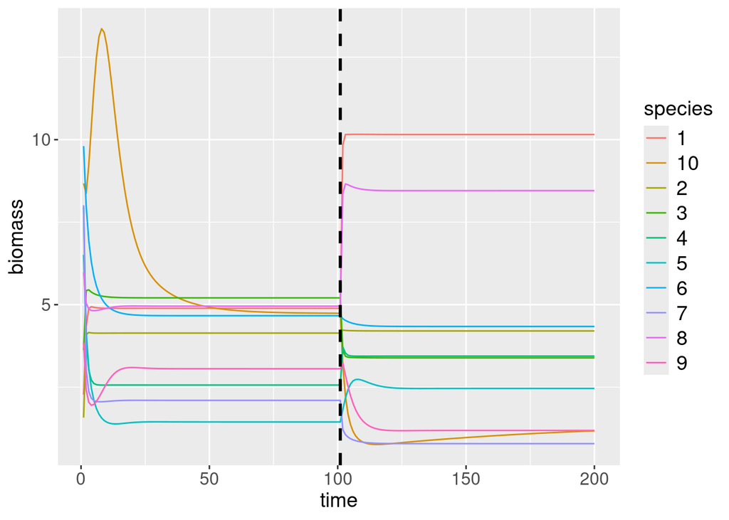

## Step 4: Calculate network coherence

The objective of the simulation is to explore the consequences of network coherence on the response of a community to a perturbation. So, the final step is to calculate network coherence. Here, network coherence is a vector where each element represent how “coherent” a species is with its community. We calculate coherence of species $i$ as the covariance between the net effects of all other species ($a_{ij}^{-1}$, $j \neq i$) and the intrinsic responses of $\Delta r_{j \neq i}$.

Here is the function:

```r
      net_coherence3
```

```
## function (delta_r, A)
## {
##     Ainv <- solve(A)
##     nc <- c()
##     for (i in 1:nrow(A)) {
##         nc <- c(nc, cov(Ainv[i, -i], delta_r[-i]))
##     }
##     return(nc)
## }
```

And here is the network coherence for our example:

```r
      NC <- net_coherence3(delta_r, A)
      NC
```

```
##  [1] -0.05289803  0.01335863  0.09583225  0.28228654  0.11400635 -0.04795874
##  [7] -0.11368665 -0.01476557  0.25486278 -2.01646717
```